# IODS course project

### Logistic regression

```r
model1 <- glm(high_use ~ romantic + studytime + G3 + absences, data = data, family = "binomial")
summary(model1)
```

```
##
## Call:
## glm(formula = high_use ~ romantic + studytime + G3 + absences,
##     family = "binomial", data = data)
##
## Deviance Residuals:
##     Min       1Q   Median       3Q      Max
## -2.1351  -0.8344  -0.6524   1.1673   2.2174
##
## Coefficients:
##             Estimate Std. Error z value Pr(>|z|)
## (Intercept)  0.59249    0.52242   1.134 0.256737
## romanticyes -0.28405    0.26416  -1.075 0.282246
## studytime   -0.52054    0.15777  -3.299 0.000969 ***
## G3          -0.06268    0.03718  -1.686 0.091764 .
## absences     0.07846    0.02298   3.414 0.000641 ***
## ---
## Signif. codes:  0 '***' 0.001 '**' 0.01 '*' 0.05 '.' 0.1 ' ' 1
##
## (Dispersion parameter for binomial family taken to be 1)
##
##     Null deviance: 452.04  on 369  degrees of freedom
## Residual deviance: 416.23  on 365  degrees of freedom
## AIC: 426.23
##
## Number of Fisher Scoring iterations: 4
```

```r
or <- exp(coef(model1)) # odds ratios
ci <- exp(confint(model1)) # confidence intervals
cbind(or, ci)
```

```
##                    or     2.5 %    97.5 %
## (Intercept) 1.8084885 0.6503605 5.0803999
## romanticyes 0.7527295 0.4441021 1.2542460
## studytime   0.5941992 0.4317881 0.8027044
## G3          0.9392402 0.8727328 1.0101465
## absences    1.0816226 1.0363169 1.1343062
```

According to model summary, higher number of absences and less study time are statistically related to heavy alcohol use. Final grade scores and romantic relationship are not statistically related to heavy alcohol use after accounting for effects of number of absences and study time. Inspecting odds ratios and their confidence intervals shows same story. The odds of people having x+1 number of absence being heavy alcohol users is between about 104% and 113% of the odds of people having x number of absence. Also, the odds of people in one higher study time category being heavy alcohol users is between about 43% and 80% of the odds of people in one lower study time category.

### Predictive power of the model with only statistically significant predictors

```r
model2 <- glm(high_use ~ studytime + absences, data = data, family = "binomial") # model with only statistically significant predictors
probabilities <- predict(model2, type = "response")
data <- mutate(data, probability = probabilities)
data <- mutate(data, prediction = probability > 0.5)
table(high_use = data$high_use, prediction = data$prediction) %>% prop.table() %>% addmargins()
```

```
##         prediction
## high_use      FALSE       TRUE        Sum
##    FALSE 0.67027027 0.02972973 0.70000000
##    TRUE  0.25135135 0.04864865 0.30000000
##    Sum   0.92162162 0.07837838 1.00000000
```

# Assignment 4: Clustering and classification

```r
date()
```

```
## [1] "Mon Dec 12 22:44:53 2022"
```

### Libraries

```r
library(psych)
library(tidyverse)
library(MASS)
```

```r
library(corrplot)
library(GGally)
```

### Exploring the data

```r
data("Boston")
dim(Boston)
```

```
## [1] 506  14
```

```r
str(Boston)
```

```
## 'data.frame':    506 obs. of  14 variables:
##  $ crim   : num  0.00632 0.02731 0.02729 0.03237 0.06905 ...
##  $ zn     : num  18 0 0 0 0 0 12.5 12.5 12.5 12.5 ...
##  $ indus  : num  2.31 7.07 7.07 2.18 2.18 2.18 7.87 7.87 7.87 7.87 ...
##  $ chas   : int  0 0 0 0 0 0 0 0 0 0 ...
##  $ nox    : num  0.538 0.469 0.469 0.458 0.458 0.458 0.524 0.524 0.524 0.524 ...
##  $ rm     : num  6.58 6.42 7.18 7 7.15 ...
##  $ age    : num  65.2 78.9 61.1 45.8 54.2 58.7 66.6 96.1 100 85.9 ...
##  $ dis    : num  4.09 4.97 4.97 6.06 6.06 ...
##  $ rad    : int  1 2 2 3 3 3 5 5 5 5 ...
##  $ tax    : num  296 242 242 222 222 222 311 311 311 311 ...
##  $ ptratio: num  15.3 17.8 17.8 18.7 18.7 18.7 15.2 15.2 15.2 15.2 ...
##  $ black  : num  397 397 393 395 397 ...
##  $ lstat  : num  4.98 9.14 4.03 2.94 5.33 ...
##  $ medv   : num  24 21.6 34.7 33.4 36.2 28.7 22.9 27.1 16.5 18.9 ...
```

The data describes the housing values in suburbs of Boston. It contains 506 observations and 14 variables.

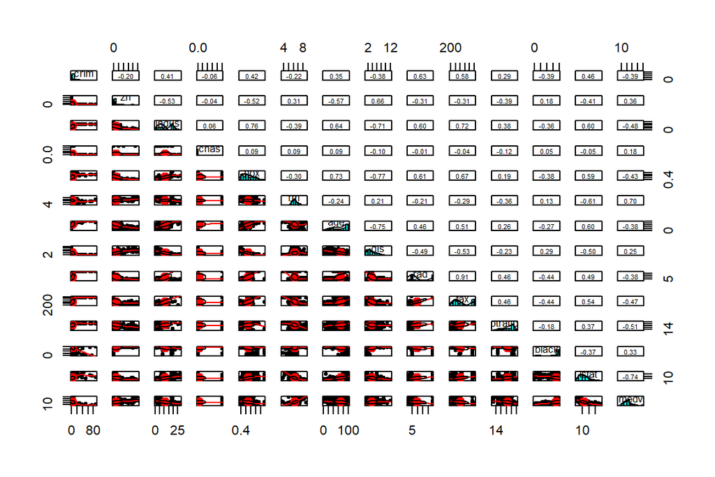

```r
pairs.panels(Boston)
```

```r
summary(Boston)
```

```
##       crim                zn             indus            chas
##  Min.   : 0.00632   Min.   :  0.00   Min.   : 0.46   Min.   :0.00000
##  1st Qu.: 0.08205   1st Qu.:  0.00   1st Qu.: 5.19   1st Qu.:0.00000
##  Median : 0.25651   Median :  0.00   Median : 9.69   Median :0.00000
##  Mean   : 3.61352   Mean   : 11.36   Mean   :11.14   Mean   :0.06917
##  3rd Qu.: 3.67708   3rd Qu.: 12.50   3rd Qu.:18.10   3rd Qu.:0.00000
##  Max.   :88.97620   Max.   :100.00   Max.   :27.74   Max.   :1.00000
##       nox               rm             age              dis
##  Min.   :0.3850   Min.   :3.561   Min.   :  2.90   Min.   : 1.130
##  1st Qu.:0.4490   1st Qu.:5.886   1st Qu.: 45.02   1st Qu.: 2.100
##  Median :0.5380   Median :6.208   Median : 77.50   Median : 3.207
##  Mean   :0.5547   Mean   :6.285   Mean   : 68.57   Mean   : 3.795
##  3rd Qu.:0.6240   3rd Qu.:6.623   3rd Qu.: 94.08   3rd Qu.: 5.188
##  Max.   :0.8710   Max.   :8.780   Max.   :100.00   Max.   :12.127
##       rad              tax           ptratio          black
##  Min.   : 1.000   Min.   :187.0   Min.   :12.60   Min.   :  0.32
##  1st Qu.: 4.000   1st Qu.:279.0   1st Qu.:17.40   1st Qu.:375.38
##  Median : 5.000   Median :330.0   Median :19.05   Median :391.44
##  Mean   : 9.549   Mean   :408.2   Mean   :18.46   Mean   :356.67
##  3rd Qu.:24.000   3rd Qu.:666.0   3rd Qu.:20.20   3rd Qu.:396.23
##  Max.   :24.000   Max.   :711.0   Max.   :22.00   Max.   :396.90
##      lstat            medv
##  Min.   : 1.73   Min.   : 5.00
##  1st Qu.: 6.95   1st Qu.:17.02
##  Median :11.36   Median :21.20
##  Mean   :12.65   Mean   :22.53
##  3rd Qu.:16.95   3rd Qu.:25.00
##  Max.   :37.97   Max.   :50.00
```

The distributions of the variables are various. Only variable rm seems to be approximately normally distributed. All of the other variables are either highly skewed, dichotomical or have multiple peaks.

### Scaling the whole dataset

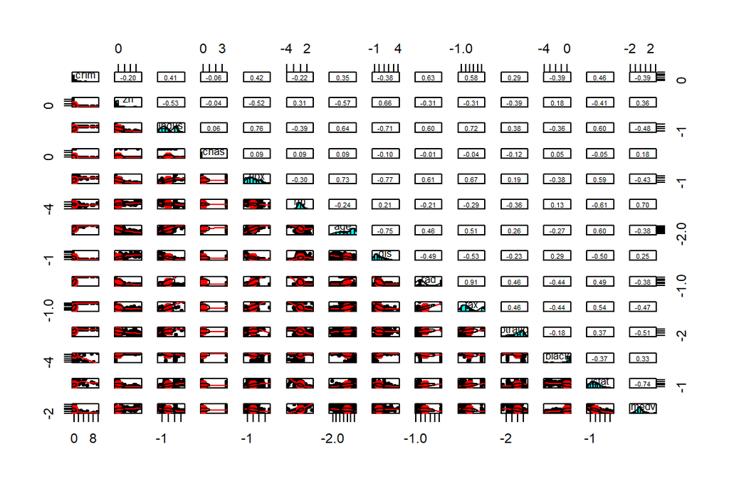

```r
boston_scaled <- scale(Boston)
boston_scaled <- as.data.frame(boston_scaled) # data frame
pairs.panels(boston_scaled)
```

```r
summary(boston_scaled)
```

```
##       crim                 zn               indus              chas
##  Min.   :-0.419367   Min.   :-0.48724   Min.   :-1.5563   Min.   :-0.2723
##  1st Qu.:-0.410563   1st Qu.:-0.48724   1st Qu.:-0.8668   1st Qu.:-0.2723
##  Median :-0.390280   Median :-0.48724   Median :-0.2109   Median :-0.2723
##  Mean   : 0.000000   Mean   : 0.00000   Mean   : 0.0000   Mean   : 0.0000
##  3rd Qu.: 0.007389   3rd Qu.: 0.04872   3rd Qu.: 1.0150   3rd Qu.:-0.2723
##  Max.   : 9.924110   Max.   : 3.80047   Max.   : 2.4202   Max.   : 3.6648
##       nox                rm               age               dis
##  Min.   :-1.4644   Min.   :-3.8764   Min.   :-2.3331   Min.   :-1.2658
##  1st Qu.:-0.9121   1st Qu.:-0.5681   1st Qu.:-0.8366   1st Qu.:-0.8049
##  Median :-0.1441   Median :-0.1084   Median : 0.3171   Median :-0.2790
##  Mean   : 0.0000   Mean   : 0.0000   Mean   : 0.0000   Mean   : 0.0000
##  3rd Qu.: 0.5981   3rd Qu.: 0.4823   3rd Qu.: 0.9059   3rd Qu.: 0.6617
##  Max.   : 2.7296   Max.   : 3.5515   Max.   : 1.1164   Max.   : 3.9566
##       rad               tax             ptratio            black
##  Min.   :-0.9819   Min.   :-1.3127   Min.   :-2.7047   Min.   :-3.9033
##  1st Qu.:-0.6373   1st Qu.:-0.7668   1st Qu.:-0.4876   1st Qu.: 0.2049
##  Median :-0.5225   Median :-0.4642   Median : 0.2746   Median : 0.3808
##  Mean   : 0.0000   Mean   : 0.0000   Mean   : 0.0000   Mean   : 0.0000
##  3rd Qu.: 1.6596   3rd Qu.: 1.5294   3rd Qu.: 0.8058   3rd Qu.: 0.4332
##  Max.   : 1.6596   Max.   : 1.7964   Max.   : 1.6372   Max.   : 0.4406
##      lstat              medv
##  Min.   :-1.5296   Min.   :-1.9063
##  1st Qu.:-0.7986   1st Qu.:-0.5989
##  Median :-0.1811   Median :-0.1449
##  Mean   : 0.0000   Mean   : 0.0000
##  3rd Qu.: 0.6024   3rd Qu.: 0.2683
##  Max.   : 3.5453   Max.   : 2.9865
```

The variables are now scaled to have mean = 0 and sd = 1.

### Test and train datasets

```r
bins <- quantile(boston_scaled$crim)
crime <- cut(boston_scaled$crim, breaks = bins, include.lowest = TRUE)
boston_scaled$crim <- crime

n <- nrow(boston_scaled)
ind <- sample(n,  size = n * 0.8)
train <- boston_scaled[ind,]
test <- boston_scaled[-ind,]
```

### Linear discriminant analysis

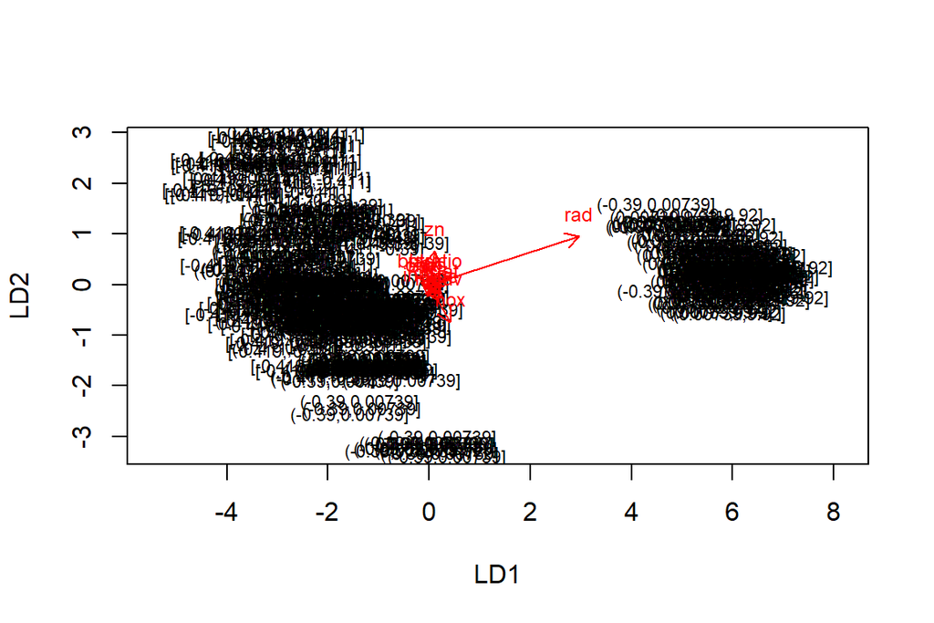

```r
lda.fit <- lda(crim ~ ., data = train)

lda.arrows <- function(x, myscale = 1, arrow_heads = 0.1, color = "red", tex = 0.75, choices = c(1,2)){
  heads <- coef(x)
  arrows(x0 = 0, y0 = 0,
         x1 = myscale * heads[,choices[1]],
         y1 = myscale * heads[,choices[2]], col=color, length = arrow_heads)
  text(myscale * heads[,choices], labels = row.names(heads),
       cex = tex, col=color, pos=3)
}

classes <- as.numeric(train$crim)

plot(lda.fit, dimen = 2)
lda.arrows(lda.fit, myscale = 1)
```

Looks like rad (index of accessibility to radial highways) has quite strongly its own dimension whereas other dimensions are more grouped together.

### Predict crime classes with the LDA model

```r
correct_classes <- test$crim
test <- dplyr::select(test, -crim)

lda.pred <- predict(lda.fit, newdata = test)
table(correct = correct_classes, predicted = lda.pred$class)
```

```
##                  predicted
## correct           [-0.419,-0.411] (-0.411,-0.39] (-0.39,0.00739] (0.00739,9.92]
##   [-0.419,-0.411]              16              6               0              0
##   (-0.411,-0.39]                3             14               5              0
##   (-0.39,0.00739]               0              5              18              0
##   (0.00739,9.92]                0              0               0             35
```

### Clustering the data

First with 3 clusters.

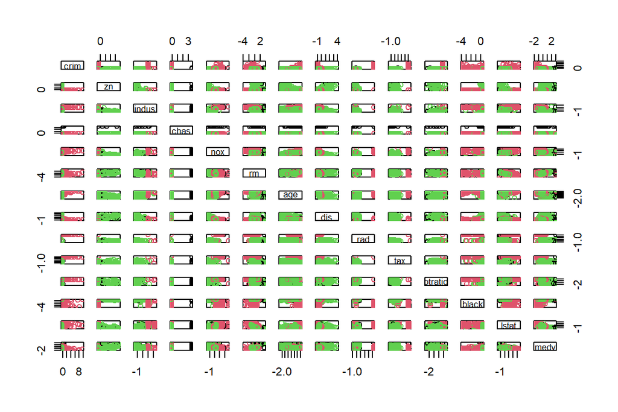

```r
boston_scaled <- scale(Boston)
boston_scaled <- as.data.frame(boston_scaled) # data frame

dist_eu <- dist(boston_scaled, method = "euclidean")
dist_man <- dist(boston_scaled, method = "manhattan")

km <- kmeans(boston_scaled, centers = 3)
pairs(boston_scaled, col = km$cluster)
```

With 4 clusters.

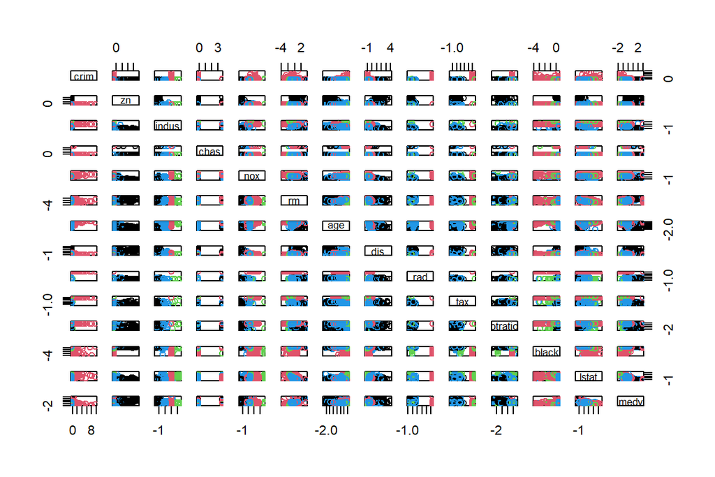

```r
km <- kmeans(boston_scaled, centers = 4)
pairs(boston_scaled, col = km$cluster)
```

With 5 clusters.

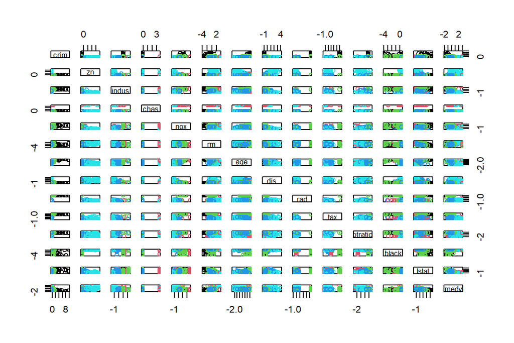

```r
km <- kmeans(boston_scaled, centers = 5)
pairs(boston_scaled, col = km$cluster)
```

Visually it seems that the best amount of clusters is 4. With 5 clusters there are too much overlapping and some clusters do not have clear groups in any of the bivariate scatterplots.

Lets check if this interpretation holds with total within sum of squares analysis.

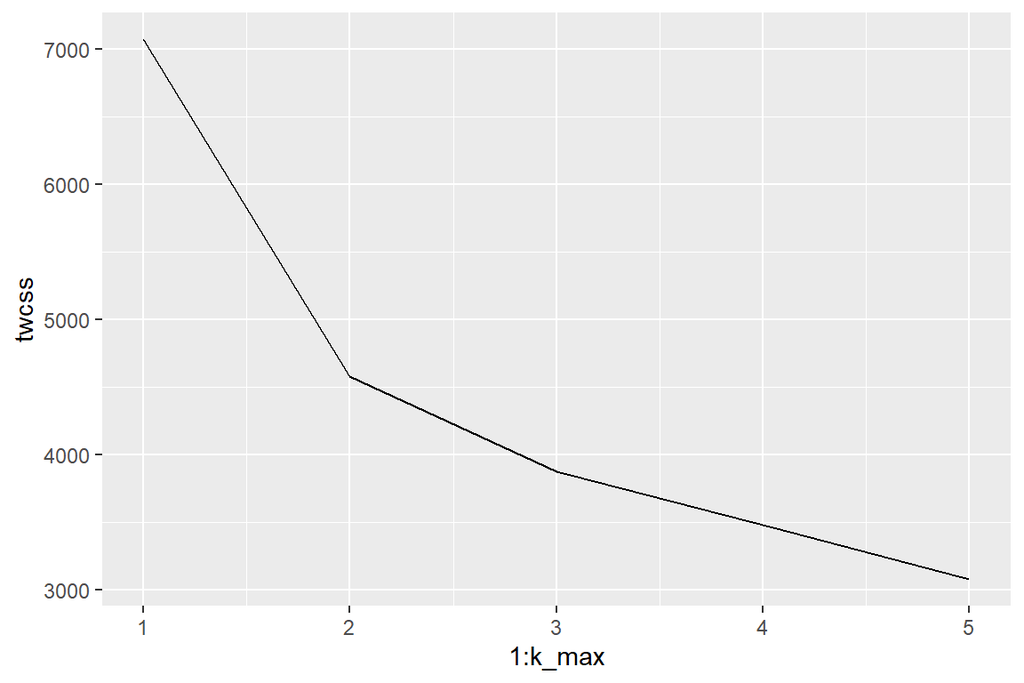

```r
k_max <- 5

# calculate the total within sum of squares
twcss <- sapply(1:k_max, function(k){kmeans(boston_scaled, k)$tot.withinss})

qplot(x = 1:k_max, y = twcss, geom = 'line')
```

### Bonus

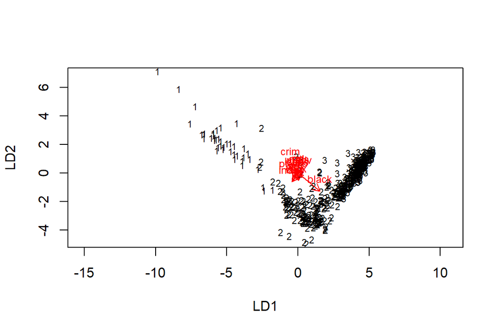

```r
boston_scaled <- scale(Boston)
boston_scaled <- as.data.frame(boston_scaled) # data frame

km <- kmeans(boston_scaled, centers = 3)
boston_scaled$cluster <- km$cluster

lda.fit <- lda(cluster ~ ., data = boston_scaled)

lda.arrows <- function(x, myscale = 1, arrow_heads = 0.1, color = "red", tex = 0.75, choices = c(1,2)){
  heads <- coef(x)
  arrows(x0 = 0, y0 = 0,
         x1 = myscale * heads[,choices[1]],
         y1 = myscale * heads[,choices[2]], col=color, length = arrow_heads)
  text(myscale * heads[,choices], labels = row.names(heads),
       cex = tex, col=color, pos=3)
}

plot(lda.fit, dimen = 2)
lda.arrows(lda.fit, myscale = 1)
```

# Assignment 5: Dimensionality reduction techniques

```r
date()
```

```
## [1] "Mon Dec 12 22:45:18 2022"
```

### Libraries

```r
library(tidyverse)
library(psych)
library(corrplot)
library(FactoMineR)
```

### Load the data

```r
setwd("C:/LocalData/salailja/IODS/IODS-project/")
human <- read_csv("data/humandata.csv")
```

### Overview of the data

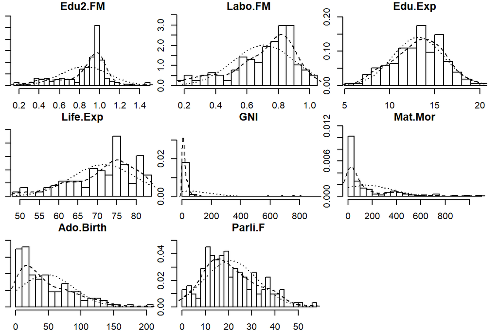

```r
multi.hist(human, global = F)
```

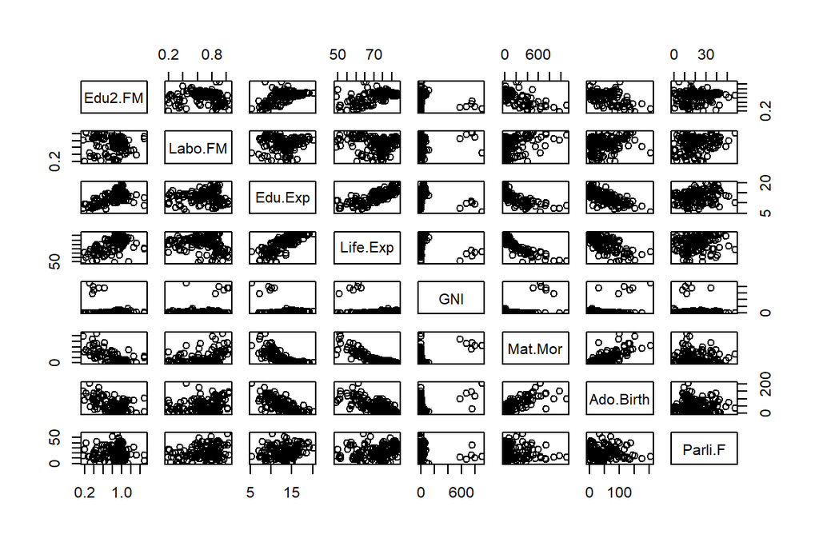

```r
pairs(human)
```

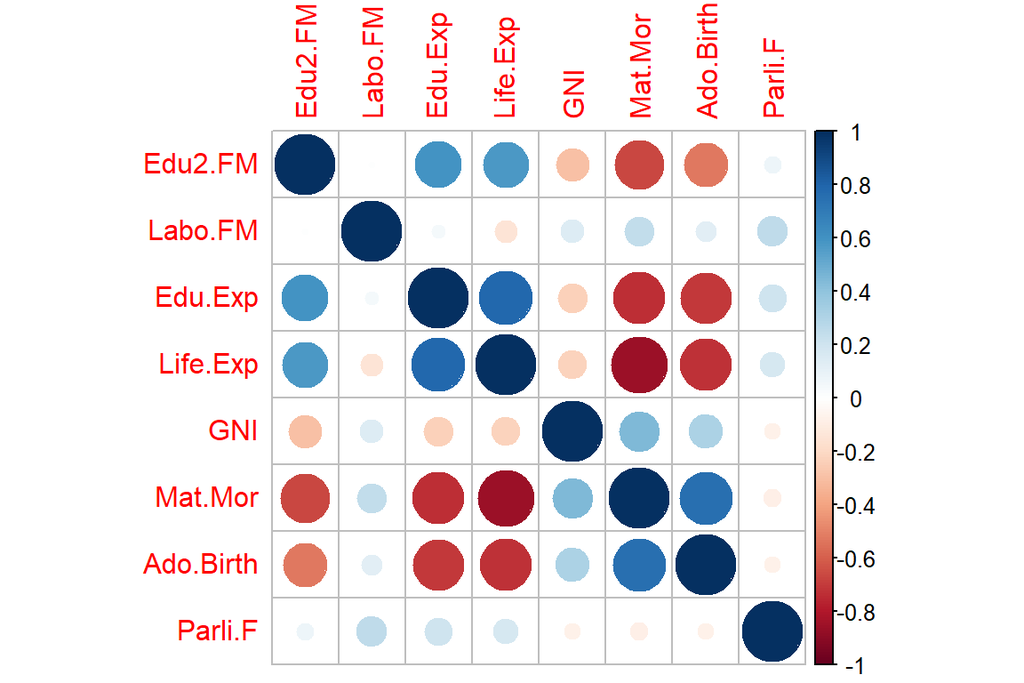

```r
corrplot(cor(human))
```

```r
summary(human)
```

```
##     Edu2.FM          Labo.FM          Edu.Exp         Life.Exp
##  Min.   :0.1717   Min.   :0.1857   Min.   : 5.40   Min.   :49.00
##  1st Qu.:0.7264   1st Qu.:0.5984   1st Qu.:11.25   1st Qu.:66.30
##  Median :0.9375   Median :0.7535   Median :13.50   Median :74.20
##  Mean   :0.8529   Mean   :0.7074   Mean   :13.18   Mean   :71.65
##  3rd Qu.:0.9968   3rd Qu.:0.8535   3rd Qu.:15.20   3rd Qu.:77.25
##  Max.   :1.4967   Max.   :1.0380   Max.   :20.20   Max.   :83.50
##       GNI             Mat.Mor         Ado.Birth         Parli.F
##  Min.   :  1.123   Min.   :   1.0   Min.   :  0.60   Min.   : 0.00
##  1st Qu.:  5.275   1st Qu.:  11.5   1st Qu.: 12.65   1st Qu.:12.40
##  Median : 13.054   Median :  49.0   Median : 33.60   Median :19.30
##  Mean   : 46.496   Mean   : 149.1   Mean   : 47.16   Mean   :20.91
##  3rd Qu.: 27.256   3rd Qu.: 190.0   3rd Qu.: 71.95   3rd Qu.:27.95
##  Max.   :908.000   Max.   :1100.0   Max.   :204.80   Max.   :57.50
```

Many of the variables are quite skewed (especially GNI), and many of them are strongly correlated to each other, which is not surprising. There are also some non-linear tendencies between some variables, such as Edu.Exp (Expected years of schooling) and Mat.Mor (Maternal mortality ratio).

### Principal component analysis with biplot

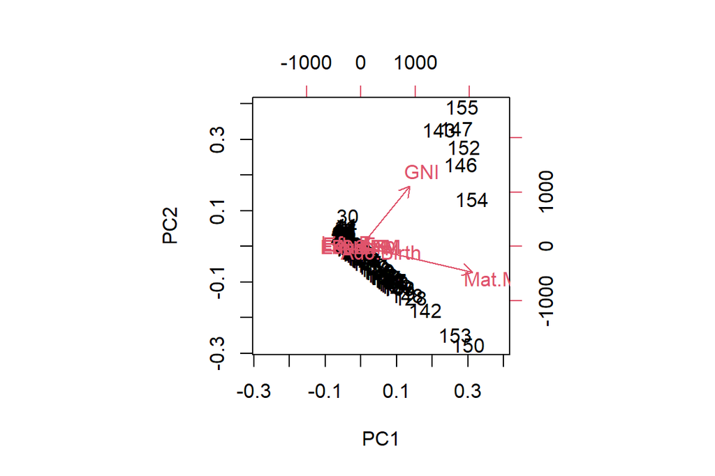

```r
pca_human <- prcomp(human)
biplot(pca_human, choices = 1:2)
```

It seems that GNI and Mat.Mor are the main sources of variability related to first two principal components. This is not surprising, since both of these variables are highly skewed and thus are likely to be much more responsible of the shared variance than the other variables.

### Repeating PCA with standardized variables

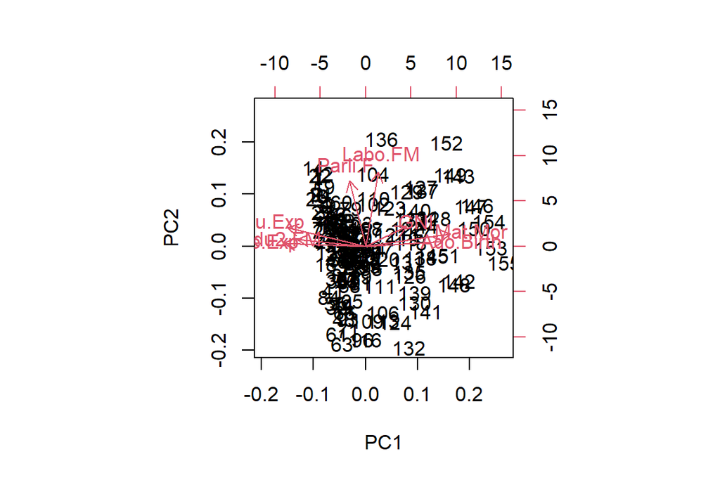

```r
human_std <- scale(human)
pca_human_std <- prcomp(human_std)
biplot(pca_human_std, choices = 1:2)
```

The plot is clearly different from the previous one, and the reason was described above. Standardization scaled the variables to same scale, and therefore GNI and Mat.Mor are not so much responsible of the variance anymore. In the latter biplot, GNI seems to have more clear loadings in two main components.

One can see that the two main components tell us about the socioeconomics (PC1) and gender equality (PC2). From the gender equality axis it looks like that Rwanda and Burundi have high percentage of females in parliament and in the labour force, whereas in Iran and Yemen the rate is low. From the socioeconomical axis it can be seen that Niger and Chad, for example, have high maternal mortality and adolescent birth rate, but low life expectancy and expected years of schooling. In the other end, there are for example Venezuela and Iran, which is also low in gender equality. From here, we can see that these two components are clearly not enough to tell us about the variance between countries.

### Multiple Correspondence Analysis on the tea data

```r
tea <- read.csv("https://raw.githubusercontent.com/KimmoVehkalahti/Helsinki-Open-Data-Science/master/datasets/tea.csv", stringsAsFactors = TRUE) # Load the tea data
str(tea); dim(tea)
```

```
## 'data.frame':    300 obs. of  36 variables:
##  $ breakfast       : Factor w/ 2 levels "breakfast","Not.breakfast": 1 1 2 2 1 2 1 2 1 1 ...
##  $ tea.time        : Factor w/ 2 levels "Not.tea time",..: 1 1 2 1 1 1 2 2 2 1 ...
##  $ evening         : Factor w/ 2 levels "evening","Not.evening": 2 2 1 2 1 2 2 1 2 1 ...
##  $ lunch           : Factor w/ 2 levels "lunch","Not.lunch": 2 2 2 2 2 2 2 2 2 2 ...
##  $ dinner          : Factor w/ 2 levels "dinner","Not.dinner": 2 2 1 1 2 1 2 2 2 2 ...
##  $ always          : Factor w/ 2 levels "always","Not.always": 2 2 2 2 1 2 2 2 2 2 ...
##  $ home            : Factor w/ 2 levels "home","Not.home": 1 1 1 1 1 1 1 1 1 1 ...
##  $ work            : Factor w/ 2 levels "Not.work","work": 1 1 2 1 1 1 1 1 1 1 ...
##  $ tearoom         : Factor w/ 2 levels "Not.tearoom",..: 1 1 1 1 1 1 1 1 1 2 ...
##  $ friends         : Factor w/ 2 levels "friends","Not.friends": 2 2 1 2 2 2 1 2 2 2 ...
##  $ resto           : Factor w/ 2 levels "Not.resto","resto": 1 1 2 1 1 1 1 1 1 1 ...
##  $ pub             : Factor w/ 2 levels "Not.pub","pub": 1 1 1 1 1 1 1 1 1 1 ...
##  $ Tea             : Factor w/ 3 levels "black","Earl Grey",..: 1 1 2 2 2 2 2 1 2 1 ...
##  $ How             : Factor w/ 4 levels "alone","lemon",..: 1 3 1 1 1 1 1 3 3 1 ...
```

[output cut: 22 more lines]

```
## [1] 300  36
```

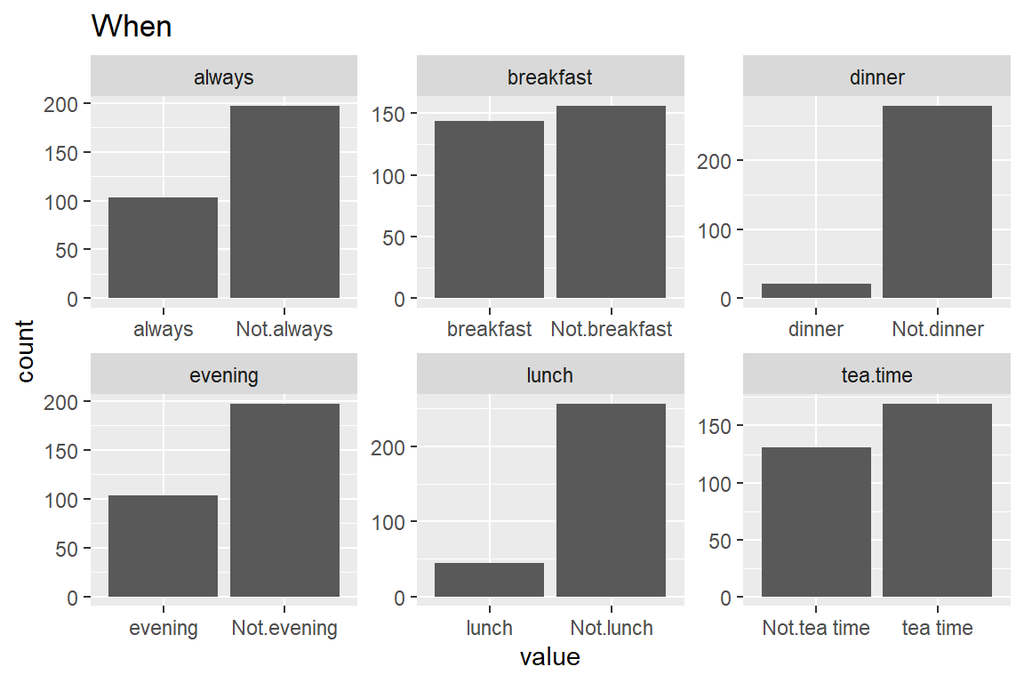

```r
#View(tea)
pivot_longer(tea, cols = 1:6) %>%
  ggplot(aes(value)) + facet_wrap("name", scales = "free") + geom_bar() + labs(title = "When")
```

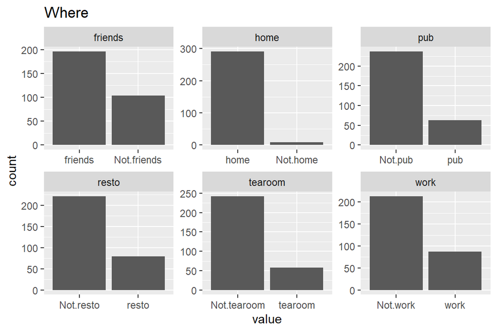

```r
pivot_longer(tea, cols = 7:12) %>%
  ggplot(aes(value)) + facet_wrap("name", scales = "free") + geom_bar() + labs(title = "Where")
```

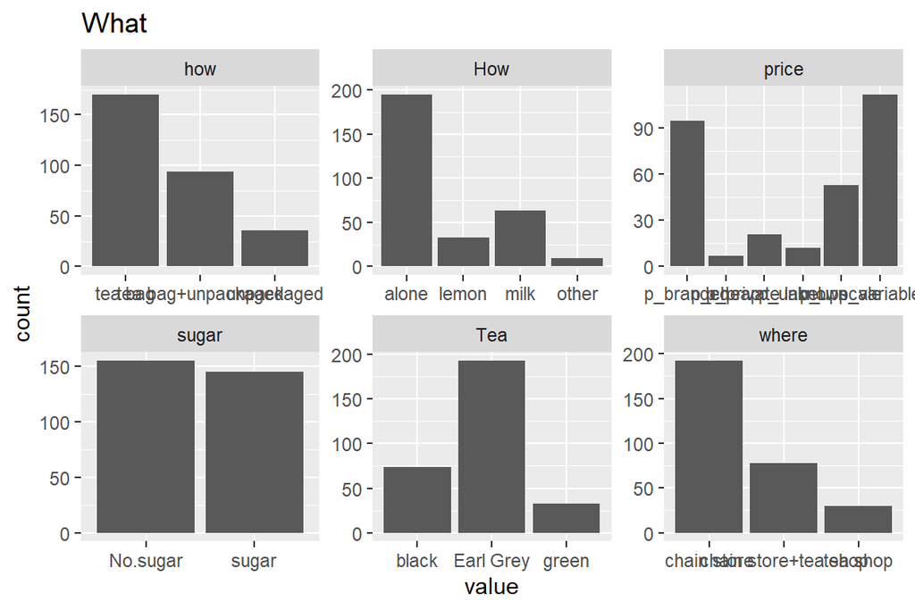

```r
pivot_longer(tea, cols = 13:18) %>%
  ggplot(aes(value)) + facet_wrap("name", scales = "free") + geom_bar() + labs(title = "What")
```

We can see that the most usual times for drinking tea are tea time and breakfast and it is usually enjoyed with friends and/or in home. As an important, but frightful, observation, around half of the people put sugar in their tea. Lets use the “What” part in the MCA analysis.

```r
tea_what <- tea[,13:18]
mca <- MCA(tea_what, graph = F)
summary(mca)
```

```
##
## Call:
## MCA(X = tea_what, graph = F)
##
##
## Eigenvalues
##                        Dim.1   Dim.2   Dim.3   Dim.4   Dim.5   Dim.6   Dim.7
## Variance               0.354   0.284   0.215   0.208   0.177   0.172   0.168
## % of var.             14.179  11.346   8.603   8.331   7.094   6.894   6.707
## Cumulative % of var.  14.179  25.525  34.128  42.458  49.553  56.447  63.154
##                        Dim.8   Dim.9  Dim.10  Dim.11  Dim.12  Dim.13  Dim.14
## Variance               0.162   0.146   0.139   0.126   0.112   0.093   0.087
## % of var.              6.477   5.849   5.579   5.059   4.469   3.711   3.471
## Cumulative % of var.  69.631  75.480  81.059  86.117  90.587  94.298  97.769
##                       Dim.15
## Variance               0.056
## % of var.              2.231
## Cumulative % of var. 100.000
##
## Individuals (the 10 first)
##              Dim.1    ctr   cos2    Dim.2    ctr   cos2    Dim.3    ctr   cos2
## 1         | -0.500  0.235  0.050 |  0.426  0.213  0.036 |  0.008  0.000  0.000
## 2         | -0.207  0.040  0.024 | -0.078  0.007  0.003 | -0.615  0.586  0.211
## 3         | -0.316  0.094  0.119 | -0.070  0.006  0.006 | -0.212  0.070  0.054
## 4         | -0.442  0.184  0.227 | -0.023  0.001  0.001 |  0.260  0.105  0.078
## 5         | -0.316  0.094  0.119 | -0.070  0.006  0.006 | -0.212  0.070  0.054
## 6         | -0.524  0.258  0.099 |  0.351  0.145  0.045 | -0.172  0.046  0.011
## 7         | -0.316  0.094  0.119 | -0.070  0.006  0.006 | -0.212  0.070  0.054
## 8         | -0.207  0.040  0.024 | -0.078  0.007  0.003 | -0.615  0.586  0.211
## 9         |  0.614  0.355  0.151 | -0.651  0.498  0.170 |  0.037  0.002  0.001
## 10        |  0.877  0.724  0.325 | -0.535  0.336  0.121 | -0.564  0.494  0.134
##
## 1         |
## 2         |
## 3         |
## 4         |
## 5         |
## 6         |
## 7         |
## 8         |
```

[output cut: 20 more lines]

```
## lemon       1.555  20.617   0.299   9.454 |
## milk        0.071   0.082   0.001   0.632 |
## other      -1.740   7.039   0.094  -5.291 |
## No.sugar   -0.635  16.154   0.431 -11.356 |
## sugar       0.679  17.268   0.431  11.356 |
## tea bag    -0.035   0.053   0.002  -0.687 |
##
## Categorical variables (eta2)
##             Dim.1 Dim.2 Dim.3
## Tea       | 0.091 0.106 0.381 |
## How       | 0.055 0.118 0.385 |
## sugar     | 0.051 0.006 0.431 |
## how       | 0.619 0.495 0.006 |
## where     | 0.700 0.651 0.060 |
## price     | 0.612 0.327 0.026 |
```

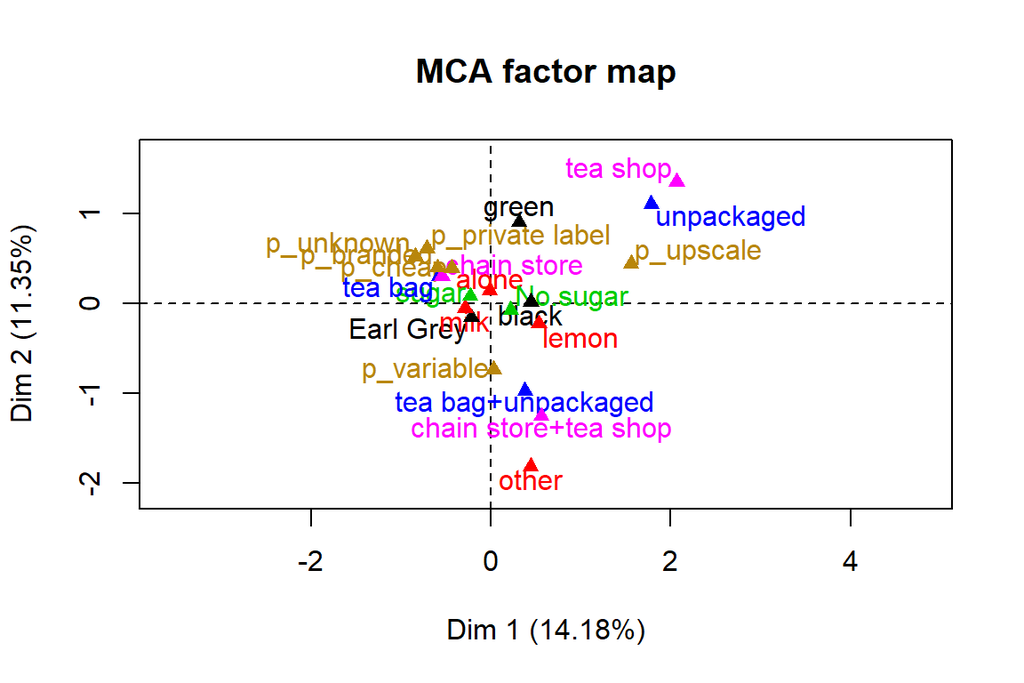

```r
plot(mca, invisible=c("ind"), graph.type = "classic", habillage = "quali")
```

The x-axis (Dim 1) clearly shows some kind of “hifi” tea factor, with upscale price and tea shop in the high end. Y-axis (Dim 2) in turn possibly shows how picky one is in their selection of particular tea, with less specific answers in the lower end.

# Assignment 6: Analysis of longitudinal data

```r
date()
```

```
## [1] "Mon Dec 12 22:45:26 2022"
```

### Libraries

```r
library(tidyverse)
```

## 1. Analysing RATS data

### Reading the data and converting categorical variables to factors

```r
setwd("C:/LocalData/salailja/IODS/IODS-project/")
bprs <- read_csv("data/bprs_long.csv")
rats <- read_csv("data/rats_long.csv")
bprs$treatment <- as.factor(bprs$treatment)
bprs$subject <- as.factor(bprs$subject)
bprs$weeks <- as.factor(bprs$weeks)
rats$ID <- as.factor(rats$ID)
rats$Group <- as.factor(rats$Group)
rats$time <- as.factor(rats$time)
```

### Graphing individual trajectories

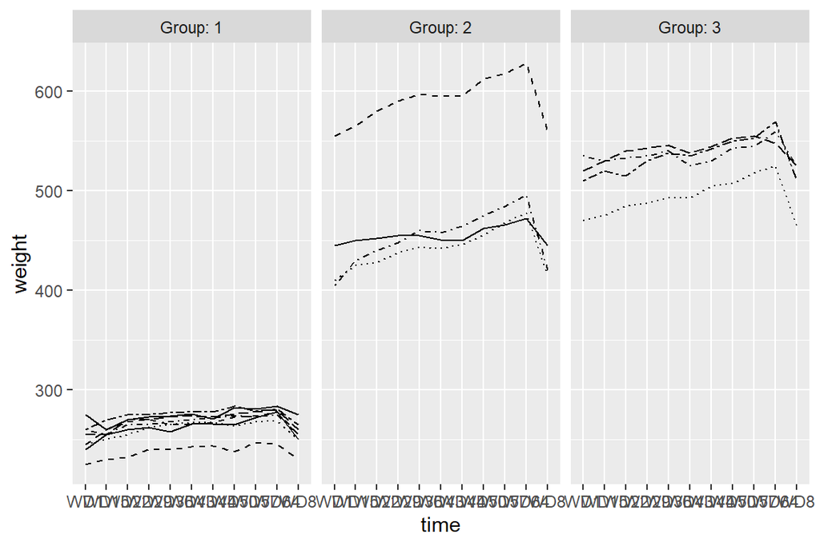

```r
ggplot(rats, aes(x = time, y = weight, group = ID, linetype = ID)) +
  geom_line() +
  scale_linetype_manual(values = rep(1:10, times=4)) +
  facet_grid(. ~ Group, labeller = label_both) +
  theme(legend.position = "none") +
  scale_y_continuous(limits = c(min(rats$weight), max(rats$weight)))
```

From here it looks like there are considerable differences in overall weight and variance between the three groups, and also within groups to some point. However, average growth of body weight looks approximately same in each group.

Lets add standardized weight variable and do the same plot again

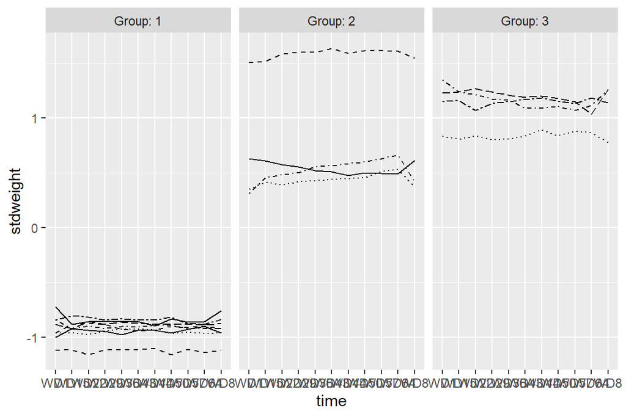

```r
rats <- rats %>%
  group_by(time) %>%
  mutate(stdweight = scale(weight)) %>%
  ungroup()

ggplot(rats, aes(x = time, y = stdweight, group = ID, linetype = ID)) +
  geom_line() +
  scale_linetype_manual(values = rep(1:10, times=4)) +
  facet_grid(. ~ Group, labeller = label_both) +
  theme(legend.position = "none")
```

Interpretation stays pretty much similar, but standardized trajectories differ more from each other than the unstandardized ones.

### Graphing summary measures

```r
rats_sum <- rats %>%
  group_by(Group, time) %>%
  summarise(mean = mean(weight), se = sd(weight)/sqrt(length(weight))) %>%
  ungroup()
```

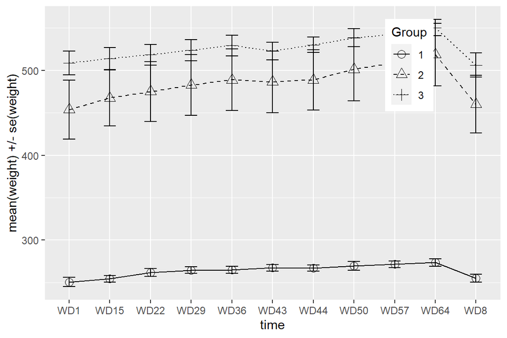

```r
ggplot(rats_sum, aes(x = time, y = mean, group = Group, linetype = Group, shape = Group)) +
  geom_line() +
  scale_linetype_manual(values = c(1,2,3)) +
  geom_point(size=3) +
  scale_shape_manual(values = c(1,2,3)) +
  geom_errorbar(aes(ymin=mean-se, ymax=mean+se, linetype="1"), width=0.3) +
  theme(legend.position = c(0.8,0.8)) +
  scale_y_continuous(name = "mean(weight) +/- se(weight)")
```

Using summary measures gives similar interpretation than plots using individual trajectories.

### Differences between groups

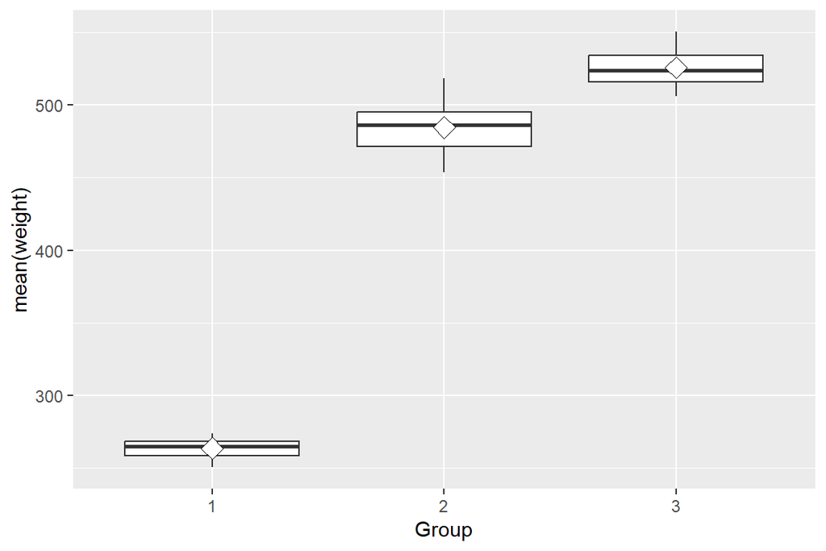

```r
ggplot(rats_sum, aes(x = Group, y = mean)) +
  geom_boxplot() +
  stat_summary(fun = "mean", geom = "point", shape=23, size=4, fill = "white") +
  scale_y_continuous(name = "mean(weight)")
```

From this boxplot we can clearly see the large difference between group 1 and other groups, and the smaller difference between groups 2 and 3.

Let’s use ANOVA to test these differences.

```r
fit <- lm(weight ~ Group, data = rats)
anova(fit)
```

```
## Analysis of Variance Table
##
## Response: weight
##            Df  Sum Sq Mean Sq F value    Pr(>F)
## Group       2 2604050 1302025  998.17 < 2.2e-16 ***
## Residuals 173  225662    1304
## ---
## Signif. codes:  0 '***' 0.001 '**' 0.01 '*' 0.05 '.' 0.1 ' ' 1
```

There are clear differences between groups as seen in previous plots.